# Working with APIs in R

Author

Casey O’Hara

Published

March 9, 2023

```r
library(sf)
library(terra)
library(tidyterra)
library(rnaturalearth)
library(tidyverse)
library(jsonlite)
library(here)
```

# API used in Shiny App

https://tylerclavelle.shinyapps.io/thePhactory/

see https://docs.phish.net/examples for API documentation.

Also, check out https://shiny.rstudio.com/articles/shinyapps.html to deploy your Shiny app online for other users. Free account is limited to 25 hours of user time per month, and better than nothing!

# Accessing IUCN API

- first: add API key to .Renviron and why do it this way?
  - in console: `usethis::edit_r_environ()`
  - add line with a useful recognizable name and your API key
  - e.g., `IUCN_KEY=12345678`
- second: accessing API key
  - now in your code, you can access this key with `api_key <- Sys.getenv('IUCN_KEY')`
- if no personal API key yet, use the API demo one:
  - 9bb4facb6d23f48efbf424bb05c0c1ef1cf6f468393bc745d42179ac4aca5fee

```r
api_key <- Sys.getenv('IUCN_KEY')

api_key <- '9bb4facb6d23f48efbf424bb05c0c1ef1cf6f468393bc745d42179ac4aca5fee'
```

## Get the IUCN Redlist version: look up the endpoint on the reference!

The documentation for the IUCN RedList REST API is very thorough, and will be useful throughout this lab to identify various endpoints for different types of queries we want to perform: https://apiv3.iucnredlist.org/api/v3/docs

Version endpoint: `/api/v3/version` (no token needed!)

```r
### append the endpoint to the domain name:
domain_name <- 'http://apiv3.iucnredlist.org'
version_end <- 'api/v3/version'

version_url <- file.path(domain_name, version_end)
api_version <- jsonlite::fromJSON(version_url)
api_version$version
```

```
[1] "2023-1"
```

## Get a count of how many species have been assessed

Here we need to use the token to access this endpoint.

spp count endpoint: `/api/v3/speciescount?token='YOUR TOKEN'`

```r
count_stem <- 'api/v3/speciescount?token=%s'
  ### a format string for sprintf - %s means replace this with character string var;
  ### lots of numeric formats supported,
  ### e.g., sprintf('%f', pi) vs sprintf('%.3f', pi)
count_end <- sprintf(count_stem, api_key)
count_url <- file.path(domain_name, count_end)

spp_count <- jsonlite::fromJSON(count_url)
spp_count$count
```

```
[1] "160647"
```

## Get a page of results

Now we can also add parameter values to the endpoint.

page endpoint: `/api/v3/species/page/:page_number?token='YOUR TOKEN'`

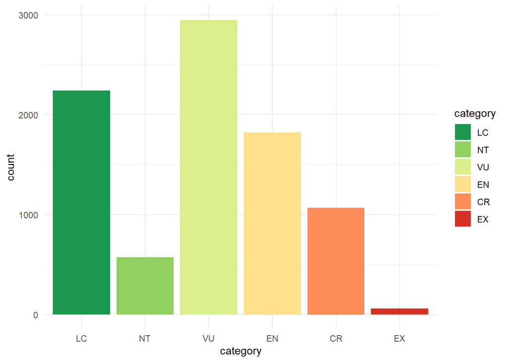

```r
page_stem <- 'api/v3/species/page/%s?token=%s'
page_end <- sprintf(page_stem, 1, api_key) ### multiple variables into format string
page_url <- file.path(domain_name, page_end)

spp_page1 <- fromJSON(page_url)

### convert extinction risk into factor and plot counts
spp_df <- spp_page1$result %>%
  mutate(category = factor(category, levels = c('LC', 'NT', 'VU', 'EN', 'CR', 'EX'))) %>%
  filter(!is.na(category))

ggplot(spp_df) +
  geom_bar(aes(x = category, fill = category)) +
  scale_fill_brewer(palette = 'RdYlGn', direction = -1) +
  theme_minimal()
```

## Get current and historic assessment info for a species

historic assessments endpoint: `/api/v3/species/history/name/:name?token='YOUR TOKEN'`

Note, spaces won’t work in a URL - need to replace them with `%20`

```r
hist_stem <- 'api/v3/species/history/name/%s?token=%s'
spp <- 'Dermochelys%20coriacea'
hist_end <- sprintf(hist_stem, spp, api_key)
hist_url <- file.path(domain_name, hist_end)

spp_hist <- fromJSON(hist_url)

spp_hist_df <- spp_hist$result

spp_hist_df
```

```
  year assess_year code              category
1 2013        2013   VU            Vulnerable
2 2000        2000   CR Critically Endangered
3 1996        1996   EN            Endangered
4 1994        1994    E            Endangered
5 1990        1990    E            Endangered
6 1988        1988    E            Endangered
7 1986        1986    E            Endangered
8 1982        1982    E            Endangered
```

## Pull threats and narrative, and extract information on gear types

Threats: `/api/v3/threats/species/name/:name?token='YOUR TOKEN'` Narratives: `/api/v3/species/narrative/:name?token='YOUR TOKEN'`

```r
threats_stem <- 'api/v3/threats/species/name/%s?token=%s'
thr_url <- file.path(domain_name, sprintf(threats_stem, spp, api_key))
spp_thr <- fromJSON(thr_url)$result

narratives_stem <- 'api/v3/species/narrative/%s?token=%s'
narr_url <- file.path(domain_name, sprintf(narratives_stem, spp, api_key))
spp_narr <- fromJSON(narr_url)$result

spp_narr$threats
```

```
[1] "<p>Threats to Leatherbacks vary in time and space, and in relative impact to populations. Threat categories affecting marine turtles, including Leatherbacks, were described by Wallace <em>et al</em>. (2011) as:</p>  <p>1) Fisheries bycatch: incidental capture of marine turtles in fishing gear t…
```

Note that the IUCN Red List site literally just calls its own API to build each page when you type in a species name!

# ERDDAP

NOAA’s [ERDDAP (Environmental Research Division Data Access Program)](https://coastwatch.pfeg.noaa.gov/erddap/index.html) site is home to thousands of datasets on environmental, biogeochemical, and ecological quantities, from satellites/remote sensing and in-situ sensors etc. These datasets can be searched through their website, but can also be accessed programmatically. Let’s search for annual precipitation data for California (latitudes 32 to 42, longitudes -114 to -125). Set the time, lat, long appropriately, and for demo purposes, let’s settle for a coarser resolution - set the stride to 5 so we’re getting every 5th point. Let’s save that out as netCDF, a raster format.

The resulting URL is: `https://coastwatch.pfeg.noaa.gov/erddap/griddap/chirps20GlobalAnnualP05.nc?precip%5B(1981-01-01T00:00:00Z):1:(2023-01-01T00:00:00Z)%5D%5B(32):5:(42)%5D%5B(-114):5:(-125)%5D`

This has already been downloaded and saved in the data folder, as `precip_ca_1981_2023.nc`.

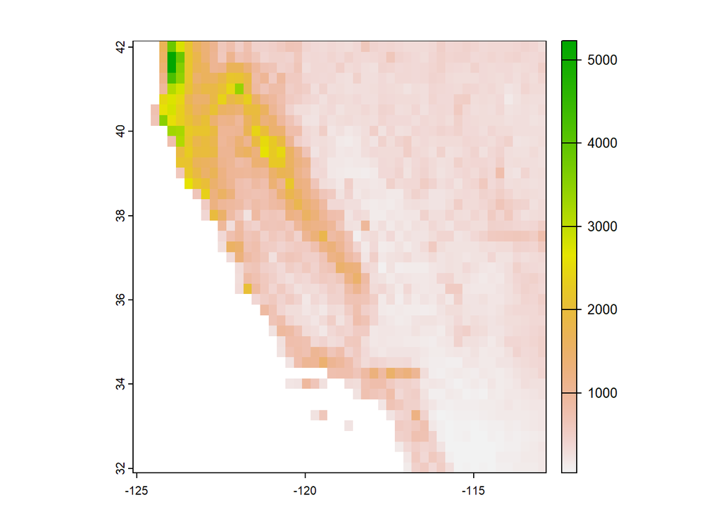

```r
precip_ca <- rast(here::here('data/precip_ca_1981_2023.nc')) %>%
  setNames(paste('precip', 1981:2023, sep = '_'))

plot(precip_ca[['precip_1998']]) ### strong El Nino year
```

But, we can also access directly using the URL:

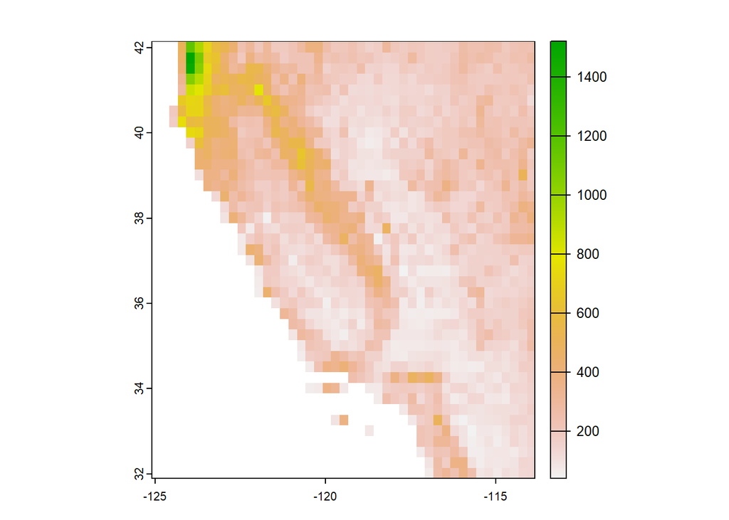

```r
precip_url <- 'https://coastwatch.pfeg.noaa.gov/erddap/griddap/chirps20GlobalAnnualP05.nc?precip%5B(1981-01-01T00:00:00Z):1:(2023-01-01T00:00:00Z)%5D%5B(32):5:(42)%5D%5B(-114):5:(-125)%5D'

precip_ca2 <- rast(precip_url) %>%
  setNames(paste('precip', 1981:2023, sep = '_'))

plot(precip_ca2[['precip_2013']]) ### drought year
```

And we can use R (or any other programming language) to automate searches and access!

```r
search_terms <- 'precipitation%20global%20annual' ### %20 to encode spaces between terms

url_stem <- 'https://coastwatch.pfeg.noaa.gov/erddap/search/index.%s?page=1&itemsPerPage=1000&searchFor=%s'

url_search1 <- sprintf(url_stem, 'json', search_terms)

result1_list <- fromJSON(url_search1)
result1_df <- as.data.frame(result1_list$table$rows) %>%
  setNames(result1_list$table$columnNames)

url_search2 <- sprintf(url_stem, 'csv', search_terms)

result2_df <- read_csv(url_search2)

result2_df$griddap[1]
```

```
[1] "https://coastwatch.pfeg.noaa.gov/erddap/griddap/chirps20GlobalAnnualP05"
```

# Map threatened status (optional, not run in lab)

Goal: per cell, calculate proportion of species considered threatened (IUCN Red List VU, EN, CR). Here, I have assembled information from the IUCN API on species names and threatened status (among other details). This is data I have used for my own research, so some columns are particular to my research needs, but not for the purposes of this lab.

I have also assembled and filtered information from AquaMaps species distributions to focus only on species present off the coast of California, including species IDs, species scientific binomial (genus species), and probability of occurrence in various cells noted by a cell ID code, LOICZID.

## Read in all the info!

Read in info about species occurrence in various spatial cells

```r
iucn_spp_info <- read_csv(here('data/iucn_marine_spp_info_2021-3.csv'))
iucn_spp_info$cat %>% unique()
```

```
[1] "vu" "cr" "nt" "lc" "dd" "en" "ex"
```

```r
### Information on cell ID (loiczid) and cell lat/long
cell_ids <- read_csv(here('data/am_latlong.csv'))

### info on species ID (am_sid), cell ID (loiczid), and probability of occurrence in that cell
spp_cells <- read_csv(here('data/am_spp_cells.csv'))

### info on the species ID (am_sid) and scientific name (binomial)
spp_ids <- read_csv(here('data/am_spp_ids.csv'))
```

## Pseudocode:

How can we combine species info, spatial info, and extinction risk info to create a map of the proportion of threatened species?

```r
spp_risk_cells <- spp_cells %>%
  inner_join(cell_ids, by = 'loiczid') %>%
  inner_join(spp_ids, by = 'am_sid') %>%
  inner_join(iucn_spp_info, by = c('binomial' = 'sciname'))

threatened_pct_cells <- spp_risk_cells %>%
  filter(prob >= 0.5) %>%
  mutate(threatened = (cat %in% c('vu', 'en', 'cr'))) %>%
  filter(cat != 'dd') %>%
  group_by(lon, lat) %>%
  summarize(pct_threatened = sum(threatened) / n())
```

## Convert cells into a raster object

If we wished to do spatial analysis with this lat-long map of percent threatened species, we can convert our grid to a raster. Don’t forget to tell it our CRS, which since we are using lat-long data, we can use WGS84, EPSG code 4326.

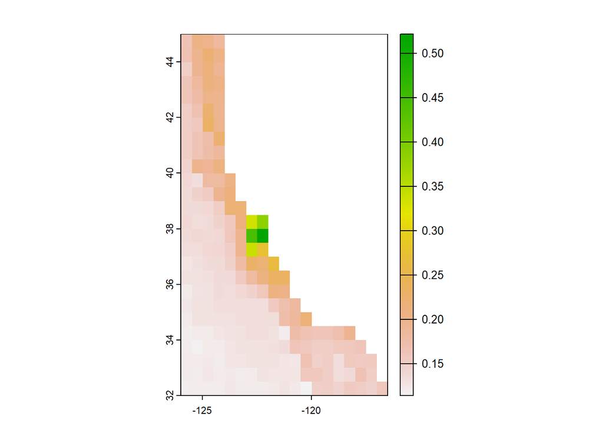

```r
spp_risk_rast <- rast(threatened_pct_cells, type = 'xyz', crs = 'epsg:4326')

plot(spp_risk_rast)
```

## Plot with ggplot

`tidyterra::geom_spatraster` can be used to plot `terra::rast` spatial rasters, just like `sf::geom_sf` can plot `sf` spatial vector objects.

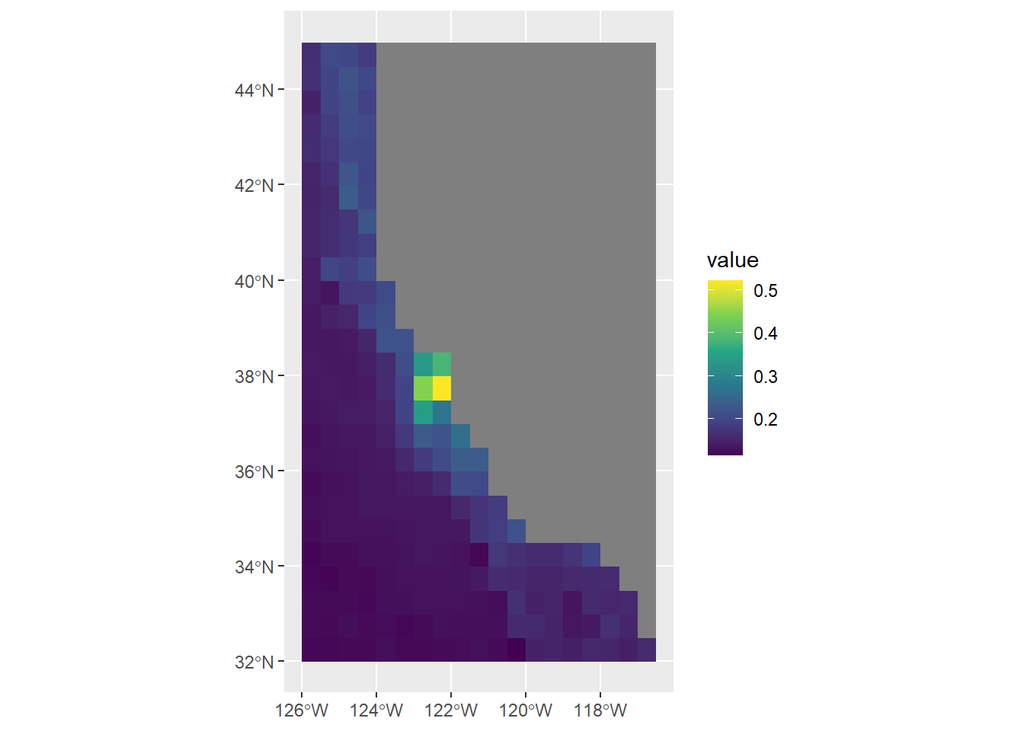

```r
p <- ggplot() +
  geom_spatraster(data = spp_risk_rast) +
  scale_fill_viridis_c()

p
```

## Let’s finalize our map by overlaying a continent shape

We will use vector data from Natural Earth, using the `rnaturalearth` package. To get higher resolution vector data of global countries, install the `rnaturalearthdata` and `rnaturalearthhires` packages too.

Note, we can access individual countries, or continents, or states; but we probably also want to crop the resulting geometry down to just our area of focus. Because we made a raster object from our grid of data, we can use that as our crop bounding box.

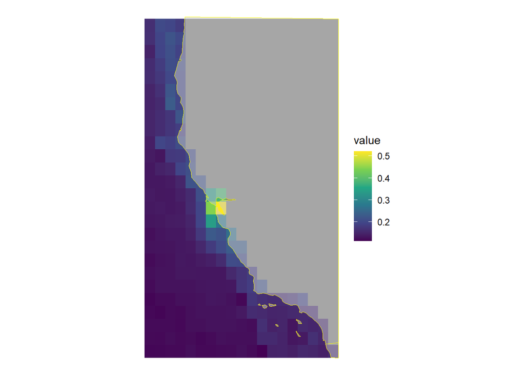

```r
land_sf <- rnaturalearth::ne_countries(scale = 50, ### start with 110
                                       country = c('united states of america', 'mexico'),
                                       returnclass = 'sf')

### if necessary: install.packages("rnaturalearthdata")

# plot(land_sf %>% select(geometry))
# st_crs(land_sf)

land_sf_cropped <- land_sf %>%
  st_crop(spp_risk_rast)

p <- p + geom_sf(data = land_sf_cropped,
                 fill = 'grey80', color = 'yellow', size = 1, alpha = .5) +
  theme_void()

p
```